# CreditCard-Customer-Segmentation

## Project - CreditCard-Customer-Segmentation

### AllLife Credit Card Customer Segmentation

#### Background

AllLife Bank wants to focus on its credit card customer base in the next financial year. They have been advised by their marketing research team, that the penetration in the market can be improved. Based on this input, the Marketing team proposes to run personalised campaigns to target new customers as well as upsell to existing customers. Another insight from the market research was that the customers perceive the support services of the back poorly. Based on this, the Operations team wants to upgrade the service delivery model, to ensure that customers queries are resolved faster. Head of Marketing and Head of Delivery both decide to reach out to the Data Science team for help.

#### Objective

To identify different segments in the existing customer based on their spending patterns as well as past interaction with the bank.

#### Key Questions:

1. How many different segments of customers are there?
2. How are these segments different from each other?
3. What are your recommendations to the bank on how to better market to and service these customers?

#### Data Description

Data is of various customers of a bank with their credit limit, the total number of credit cards the customer has, and different channels through which customer has contacted the bank for any queries, different channels include visiting the bank, online and through a call.

- Customer key - Identifier for the customer
- Average Credit Limit - Average credit limit across all the credit cards
- Total credit cards - Total number of credit cards
- Total visits bank - Total number of bank visits
- Total visits online - total number of online visits
- Total calls made - Total number of calls made by the customer

#### Steps to follow

1. Perform univariate analysis on the data to better understand the variables at your disposal and to get an idea about the no of clusters. Perform EDA, create visualizations to explore data. (10 marks)
2. Properly comment on the codes, provide explanations of the steps taken in the notebook and conclude your insights from the graphs. (5 marks)
3. Execute K-means clustering use elbow plot and analyse clusters using boxplot (10 marks)
4. Execute hierarchical clustering (with different linkages) with the help of dendrogram and cophenetic coeff. Analyse clusters formed using boxplot (15 marks)
5. Calculate average silhouette score for both methods. (5 marks)
6. Compare K-means clusters with Hierarchical clusters. (5 marks)
7. Analysis the clusters formed, tell us how is one cluster different from another and answer all the key questions. (10 marks)

#### 1. Import the necessary packages

```python
#Load Libraries
import pandas as pd
import numpy as np
import seaborn as sns
import datetime
import matplotlib.pyplot as plt
from sklearn.model_selection  import train_test_split
from sklearn.cluster import KMeans

from scipy.stats import zscore

%matplotlib inline
```

```python
import warnings
warnings.filterwarnings('ignore')
```

#### Read the dataset into dataframes

```python
from pandas import read_excel

credit_df = pd.read_excel('CreditCard_CustomerData.xlsx', sheet_name='Sheet1')
credit_df.head(10)
```

|  | Sl_No | Customer Key | Avg_Credit_Limit | Total_Credit_Cards | Total_visits_bank | Total_visits_online | Total_calls_made |
| --- | --- | --- | --- | --- | --- | --- | --- |
| 0 | 1 | 87073 | 100000 | 2 | 1 | 1 | 0 |
| 1 | 2 | 38414 | 50000 | 3 | 0 | 10 | 9 |
| 2 | 3 | 17341 | 50000 | 7 | 1 | 3 | 4 |
| 3 | 4 | 40496 | 30000 | 5 | 1 | 1 | 4 |
| 4 | 5 | 47437 | 100000 | 6 | 0 | 12 | 3 |
| 5 | 6 | 58634 | 20000 | 3 | 0 | 1 | 8 |
| 6 | 7 | 48370 | 100000 | 5 | 0 | 11 | 2 |
| 7 | 8 | 37376 | 15000 | 3 | 0 | 1 | 1 |
| 8 | 9 | 82490 | 5000 | 2 | 0 | 2 | 2 |
| 9 | 10 | 44770 | 3000 | 4 | 0 | 1 | 7 |

```python
credit_df.tail(10)
```

|  | Sl_No | Customer Key | Avg_Credit_Limit | Total_Credit_Cards | Total_visits_bank | Total_visits_online | Total_calls_made |
| --- | --- | --- | --- | --- | --- | --- | --- |
| 650 | 651 | 78996 | 195000 | 10 | 1 | 12 | 2 |
| 651 | 652 | 78404 | 132000 | 9 | 1 | 12 | 2 |
| 652 | 653 | 28525 | 156000 | 8 | 1 | 8 | 0 |
| 653 | 654 | 51826 | 95000 | 10 | 0 | 15 | 1 |
| 654 | 655 | 65750 | 172000 | 10 | 1 | 9 | 1 |
| 655 | 656 | 51108 | 99000 | 10 | 1 | 10 | 0 |
| 656 | 657 | 60732 | 84000 | 10 | 1 | 13 | 2 |
| 657 | 658 | 53834 | 145000 | 8 | 1 | 9 | 1 |
| 658 | 659 | 80655 | 172000 | 10 | 1 | 15 | 0 |
| 659 | 660 | 80150 | 167000 | 9 | 0 | 12 | 2 |

#### Apply info, shape, describe, and find the number of missing values in the data

```python
# Check to see the number of records in the dataset
credit_df.shape
```

```
(660, 7)
```

#### Observation: The dataset comprises of 660 rows and 7 columns

```python
credit_df.info()
```

```
<class 'pandas.core.frame.DataFrame'>
RangeIndex: 660 entries, 0 to 659
Data columns (total 7 columns):
 #   Column               Non-Null Count  Dtype
---  ------               --------------  -----
 0   Sl_No                660 non-null    int64
 1   Customer Key         660 non-null    int64
 2   Avg_Credit_Limit     660 non-null    int64
 3   Total_Credit_Cards   660 non-null    int64
 4   Total_visits_bank    660 non-null    int64
 5   Total_visits_online  660 non-null    int64
 6   Total_calls_made     660 non-null    int64
dtypes: int64(7)
memory usage: 36.2 KB
```

```python
credit_df.dtypes
```

```
Sl_No                  int64
Customer Key           int64
Avg_Credit_Limit       int64
Total_Credit_Cards     int64
Total_visits_bank      int64
Total_visits_online    int64
Total_calls_made       int64
dtype: object
```

```python
# Check to see if data has any missing values
credit_df.isnull().any()
```

```
Sl_No                  False
Customer Key           False
Avg_Credit_Limit       False
Total_Credit_Cards     False
Total_visits_bank      False
Total_visits_online    False
Total_calls_made       False
dtype: bool
```

#### Observation: No Null Values are present

```python
#Analyze the distribution of the dataset
credit_df.describe()
```

|  | Sl_No | Customer Key | Avg_Credit_Limit | Total_Credit_Cards | Total_visits_bank | Total_visits_online | Total_calls_made |
| --- | --- | --- | --- | --- | --- | --- | --- |
| count | 660.000000 | 660.000000 | 660.000000 | 660.000000 | 660.000000 | 660.000000 | 660.000000 |
| mean | 330.500000 | 55141.443939 | 34574.242424 | 4.706061 | 2.403030 | 2.606061 | 3.583333 |
| std | 190.669872 | 25627.772200 | 37625.487804 | 2.167835 | 1.631813 | 2.935724 | 2.865317 |
| min | 1.000000 | 11265.000000 | 3000.000000 | 1.000000 | 0.000000 | 0.000000 | 0.000000 |
| 25% | 165.750000 | 33825.250000 | 10000.000000 | 3.000000 | 1.000000 | 1.000000 | 1.000000 |
| 50% | 330.500000 | 53874.500000 | 18000.000000 | 5.000000 | 2.000000 | 2.000000 | 3.000000 |
| 75% | 495.250000 | 77202.500000 | 48000.000000 | 6.000000 | 4.000000 | 4.000000 | 5.000000 |
| max | 660.000000 | 99843.000000 | 200000.000000 | 10.000000 | 5.000000 | 15.000000 | 10.000000 |

```python
credit_df.describe(include = 'all').transpose()
```

|  | count | mean | std | min | 25% | 50% | 75% | max |
| --- | --- | --- | --- | --- | --- | --- | --- | --- |
| Sl_No | 660.0 | 330.500000 | 190.669872 | 1.0 | 165.75 | 330.5 | 495.25 | 660.0 |
| Customer Key | 660.0 | 55141.443939 | 25627.772200 | 11265.0 | 33825.25 | 53874.5 | 77202.50 | 99843.0 |
| Avg_Credit_Limit | 660.0 | 34574.242424 | 37625.487804 | 3000.0 | 10000.00 | 18000.0 | 48000.00 | 200000.0 |
| Total_Credit_Cards | 660.0 | 4.706061 | 2.167835 | 1.0 | 3.00 | 5.0 | 6.00 | 10.0 |
| Total_visits_bank | 660.0 | 2.403030 | 1.631813 | 0.0 | 1.00 | 2.0 | 4.00 | 5.0 |
| Total_visits_online | 660.0 | 2.606061 | 2.935724 | 0.0 | 1.00 | 2.0 | 4.00 | 15.0 |
| Total_calls_made | 660.0 | 3.583333 | 2.865317 | 0.0 | 1.00 | 3.0 | 5.00 | 10.0 |

```python
print(credit_df.columns)
```

```
Index(['Sl_No', 'Customer Key', 'Avg_Credit_Limit', 'Total_Credit_Cards',
       'Total_visits_bank', 'Total_visits_online', 'Total_calls_made'],
      dtype='object')
```

```python
num_cols = ['Avg_Credit_Limit', 'Total_Credit_Cards',
       'Total_visits_bank', 'Total_visits_online', 'Total_calls_made']
```

```
Attribute:  Avg_Credit_Limit
[{'mean': 34574.242424242424, 'iqr': 38000.0, 'cilo': 15677.737649566177, 'cihi': 20322.262350433823, 'whishi': 100000, 'whislo': 3000, 'fliers': array([157000, 163000, 131000, 136000, 121000, 158000, 108000, 166000,
       176000, 166000, 178000, 156000, 146000, 155000, 200000, 195000,
       187000, 163000, 106000, 114000, 126000, 173000, 153000, 184000,
       123000, 144000, 127000, 171000, 186000, 183000, 111000, 112000,
       195000, 132000, 156000, 172000, 145000, 172000, 167000]), 'q1': 10000.0, 'med': 18000.0, 'q3': 48000.0}]
```

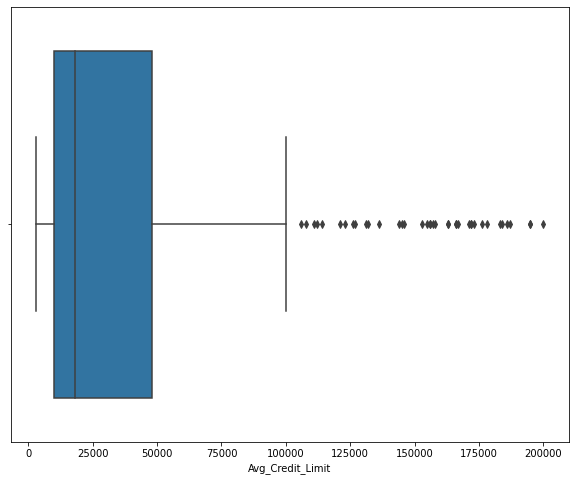

```
-------------------------------------------------------------------------
Attribute:  Total_Credit_Cards
[{'mean': 4.706060606060606, 'iqr': 3.0, 'cilo': 4.8166634986499615, 'cihi': 5.1833365013500385, 'whishi': 10, 'whislo': 1, 'fliers': array([], dtype=int64), 'q1': 3.0, 'med': 5.0, 'q3': 6.0}]
```

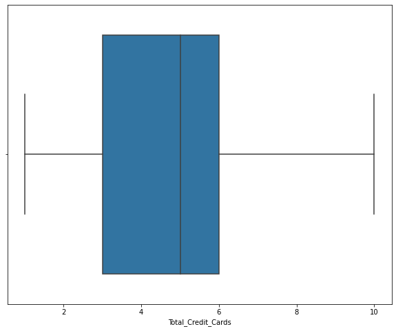

```
-------------------------------------------------------------------------
Attribute:  Total_visits_bank
[{'mean': 2.403030303030303, 'iqr': 3.0, 'cilo': 1.8166634986499615, 'cihi': 2.1833365013500385, 'whishi': 5, 'whislo': 0, 'fliers': array([], dtype=int64), 'q1': 1.0, 'med': 2.0, 'q3': 4.0}]
```

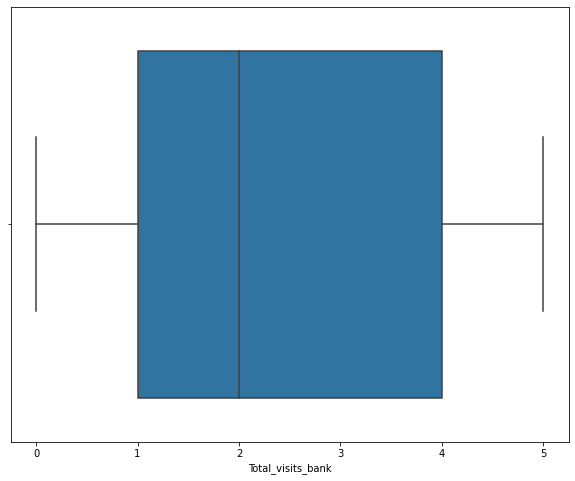

```
-------------------------------------------------------------------------
Attribute:  Total_visits_online
[{'mean': 2.606060606060606, 'iqr': 3.0, 'cilo': 1.8166634986499615, 'cihi': 2.1833365013500385, 'whishi': 8, 'whislo': 0, 'fliers': array([10, 12, 11, 14, 11, 10, 11, 13, 13, 13, 15, 12, 15, 11, 10, 12, 15,
       13, 15, 10, 11, 15, 15, 10,  9, 15, 15,  9, 12, 12, 15,  9, 10, 13,
        9, 15, 12]), 'q1': 1.0, 'med': 2.0, 'q3': 4.0}]
```

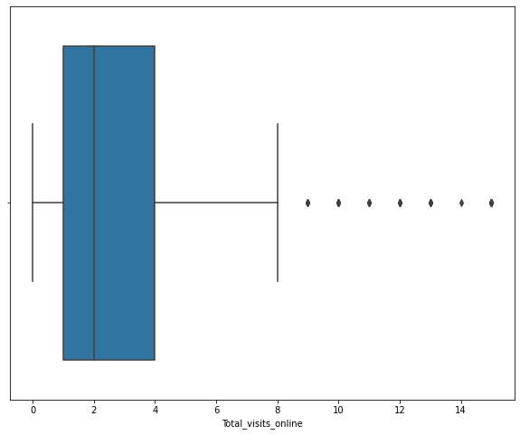

```
-------------------------------------------------------------------------
Attribute:  Total_calls_made
[{'mean': 3.5833333333333335, 'iqr': 4.0, 'cilo': 2.755551331533282, 'cihi': 3.244448668466718, 'whishi': 10, 'whislo': 0, 'fliers': array([], dtype=int64), 'q1': 1.0, 'med': 3.0, 'q3': 5.0}]
```

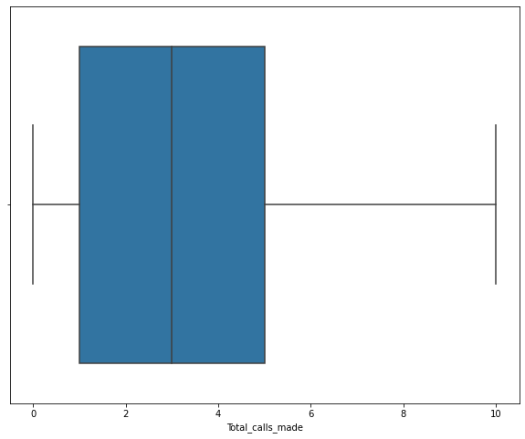

```python
from matplotlib.cbook import boxplot_stats

# Central tendency distribution
i = 1
for col in num_cols:
    print('Attribute: ',col)
    print(boxplot_stats(credit_df[col]))
    plt.figure(figsize=(10,8))
    sns.boxplot(credit_df[col])
    plt.show();
    i = i+1
    print('-------------------------------------------------------------------------')
```

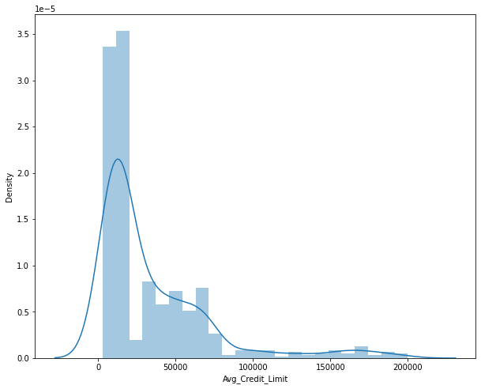

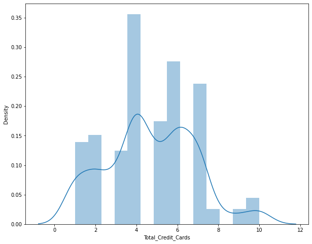

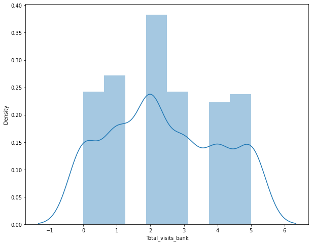

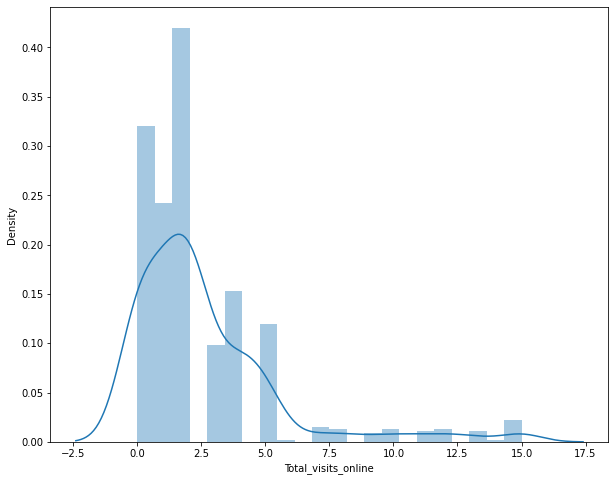

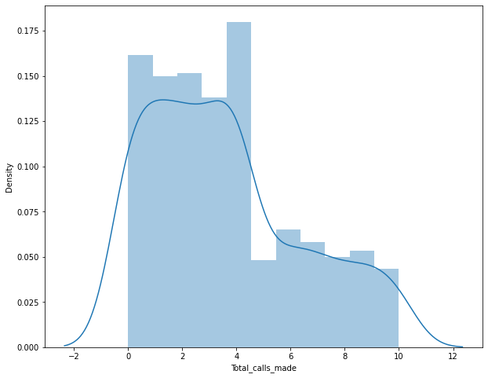

```python
# Skewness distribution
i = 1
for col in num_cols:
    plt.figure(figsize=(10,8))
    sns.distplot(credit_df[col])
    i = i+1
```

### Bi-variate analysis

```python
credit_df.corr(method='kendall')
```

|  | Sl_No | Customer Key | Avg_Credit_Limit | Total_Credit_Cards | Total_visits_bank | Total_visits_online | Total_calls_made |
| --- | --- | --- | --- | --- | --- | --- | --- |
| Sl_No | 1.000000 | 0.035219 | 0.511875 | 0.555316 | 0.301461 | -0.261829 | -0.483440 |
| Customer Key | 0.035219 | 1.000000 | 0.048772 | -0.005471 | -0.002259 | 0.005778 | -0.000494 |
| Avg_Credit_Limit | 0.511875 | 0.048772 | 1.000000 | 0.393034 | 0.082167 | -0.078739 | -0.326996 |
| Total_Credit_Cards | 0.555316 | -0.005471 | 0.393034 | 1.000000 | 0.296640 | -0.242907 | -0.492532 |
| Total_visits_bank | 0.301461 | -0.002259 | 0.082167 | 0.296640 | 1.000000 | -0.512982 | -0.373968 |
| Total_visits_online | -0.261829 | 0.005778 | -0.078739 | -0.242907 | -0.512982 | 1.000000 | 0.310855 |
| Total_calls_made | -0.483440 | -0.000494 | -0.326996 | -0.492532 | -0.373968 | 0.310855 | 1.000000 |

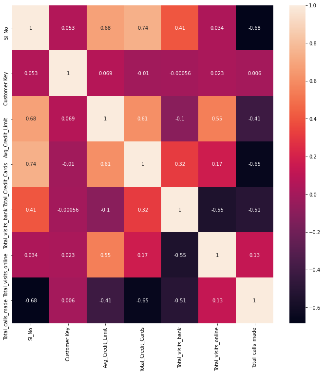

```python
plt.figure(figsize = (12, 12))
sns.heatmap(credit_df.corr(), annot=True,
            xticklabels=credit_df.columns,
            yticklabels=credit_df.columns)
```

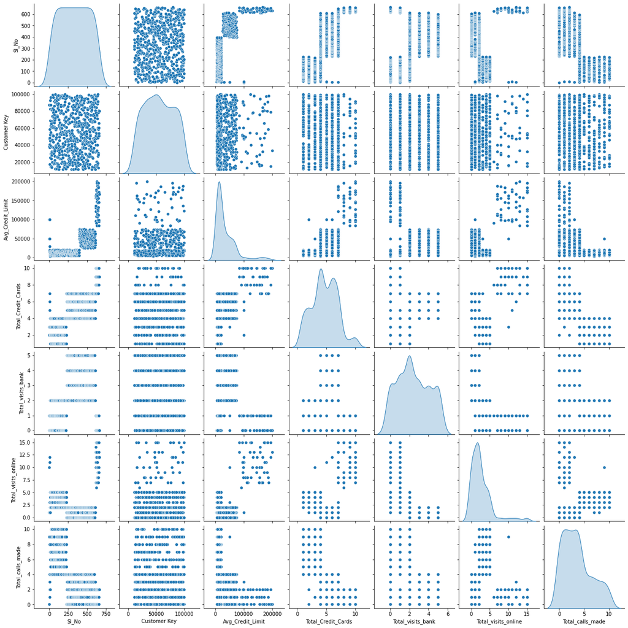

```python
sns.pairplot(credit_df,diag_kind='kde')
```

```python
# Identify duplicates records in the data

duplicates = credit_df[credit_df.duplicated('Customer Key')]
print("Duplicate Rows :")
# Print the resultant Dataframe
duplicates
```

```
Duplicate Rows :
```

|  | Sl_No | Customer Key | Avg_Credit_Limit | Total_Credit_Cards | Total_visits_bank | Total_visits_online | Total_calls_made |
| --- | --- | --- | --- | --- | --- | --- | --- |
| 332 | 333 | 47437 | 17000 | 7 | 3 | 1 | 0 |
| 398 | 399 | 96929 | 67000 | 6 | 2 | 2 | 2 |
| 432 | 433 | 37252 | 59000 | 6 | 2 | 1 | 2 |
| 541 | 542 | 50706 | 60000 | 7 | 5 | 2 | 2 |
| 632 | 633 | 97935 | 187000 | 7 | 1 | 7 | 0 |

```python
# Removing Duplicates
credit_df = credit_df.drop_duplicates(subset='Customer Key', keep='last')
print(credit_df)
```

```
     Sl_No  Customer Key  Avg_Credit_Limit  Total_Credit_Cards  \
0        1         87073            100000                   2
1        2         38414             50000                   3
2        3         17341             50000                   7
3        4         40496             30000                   5
5        6         58634             20000                   3
..     ...           ...               ...                 ...
655    656         51108             99000                  10
656    657         60732             84000                  10
657    658         53834            145000                   8
658    659         80655            172000                  10
659    660         80150            167000                   9

     Total_visits_bank  Total_visits_online  Total_calls_made
0                    1                    1                 0
1                    0                   10                 9
2                    1                    3                 4
3                    1                    1                 4
5                    0                    1                 8
..                 ...                  ...               ...
655                  1                   10                 0
656                  1                   13                 2
657                  1                    9                 1
658                  1                   15                 0
659                  0                   12                 2

[655 rows x 7 columns]
```

```python
# Check to see the number of records in the dataset
credit_df.shape
```

```
(655, 7)
```

```python
# Check the unique values in each column of the dataframe
credit_df.nunique()
```

```
Sl_No                  655
Customer Key           655
Avg_Credit_Limit       110
Total_Credit_Cards      10
Total_visits_bank        6
Total_visits_online     16
Total_calls_made        11
dtype: int64
```

```python
credit_df_new = credit_df.copy()
```

```python
# Let us now remove duplicate/irrelevant columns

credit_df_new = credit_df_new.drop(['Sl_No'], axis =1)

credit_df_new.head()
```

|  | Customer Key | Avg_Credit_Limit | Total_Credit_Cards | Total_visits_bank | Total_visits_online | Total_calls_made |
| --- | --- | --- | --- | --- | --- | --- |
| 0 | 87073 | 100000 | 2 | 1 | 1 | 0 |
| 1 | 38414 | 50000 | 3 | 0 | 10 | 9 |
| 2 | 17341 | 50000 | 7 | 1 | 3 | 4 |
| 3 | 40496 | 30000 | 5 | 1 | 1 | 4 |
| 5 | 58634 | 20000 | 3 | 0 | 1 | 8 |

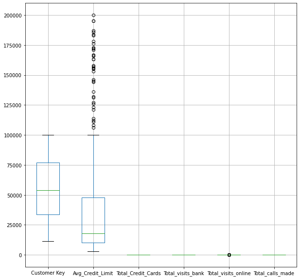

```python
plt.figure(figsize = (10, 10))
credit_df_new.boxplot();
```

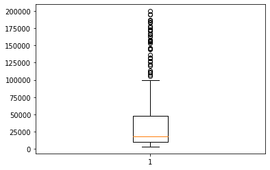

```python
# We could see some outliers for the attribute avg_credit_limit
plt.boxplot(credit_df_new['Avg_Credit_Limit']);
```

```python
# Let us take logarithmic transform the attribute avg_credit_limit to remove outliers
credit_df_new['Avg_Credit_Limit'] = np.log(credit_df_new['Avg_Credit_Limit'])
credit_df_new.head()
```

|  | Customer Key | Avg_Credit_Limit | Total_Credit_Cards | Total_visits_bank | Total_visits_online | Total_calls_made |
| --- | --- | --- | --- | --- | --- | --- |
| 0 | 87073 | 11.512925 | 2 | 1 | 1 | 0 |
| 1 | 38414 | 10.819778 | 3 | 0 | 10 | 9 |
| 2 | 17341 | 10.819778 | 7 | 1 | 3 | 4 |
| 3 | 40496 | 10.308953 | 5 | 1 | 1 | 4 |
| 5 | 58634 | 9.903488 | 3 | 0 | 1 | 8 |

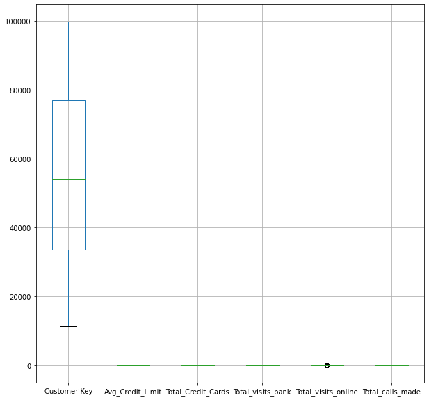

```python
plt.figure(figsize = (10, 10))
credit_df_new.boxplot();
```

```python
# Now let us try to scale the variables
credit_df1 = credit_df_new.iloc[:,1:]
credit_df_scaled = credit_df1.apply(zscore)
credit_df_scaled.head()
```

|  | Avg_Credit_Limit | Total_Credit_Cards | Total_visits_bank | Total_visits_online | Total_calls_made |
| --- | --- | --- | --- | --- | --- |
| 0 | 1.631391 | -1.249084 | -0.864813 | -0.548851 | -1.252966 |
| 1 | 0.885986 | -0.788414 | -1.480522 | 2.535493 | 1.900849 |
| 2 | 0.885986 | 1.054266 | -0.864813 | 0.136559 | 0.148730 |
| 3 | 0.336649 | 0.132926 | -0.864813 | -0.548851 | 0.148730 |
| 5 | -0.099385 | -0.788414 | -1.480522 | -0.548851 | 1.550425 |

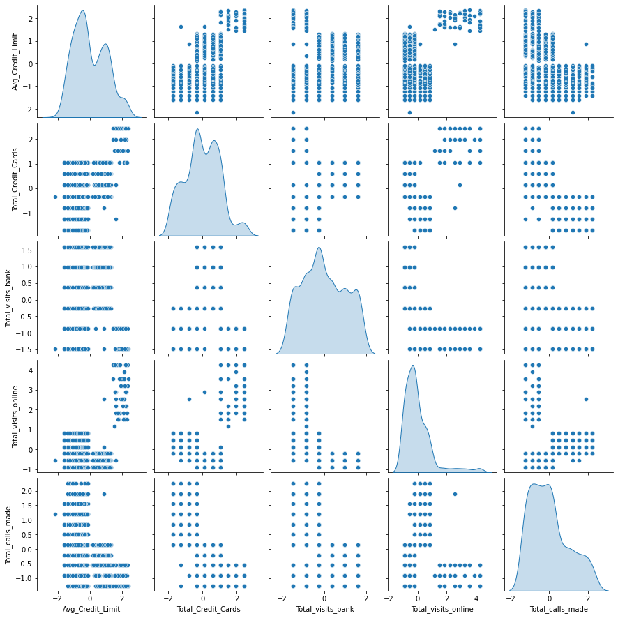

```python
sns.pairplot(credit_df_scaled,diag_kind='kde');
```

### Correlation Check

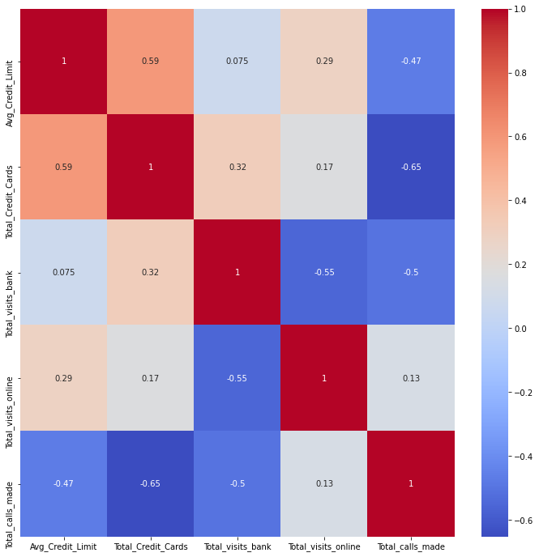

```python
plt.figure(figsize=(12,12))
sns.heatmap(credit_df_scaled.corr(), annot=True, cmap='coolwarm',
            xticklabels=credit_df_scaled.columns,
            yticklabels=credit_df_scaled.columns)
```

### Create appropriate clusters - K Means Clustering

Now, we will use K-Means clustering to group data based on their attribute. First, we need to determine the optimal number of groups. For that we conduct the knee test to see where the knee happens.

```python
# Finding optimal no. of clusters
cluster_range = range(1,10)
cluster_errors = []
for num_clusters in cluster_range:
    clusters = KMeans(num_clusters, n_init = 5,random_state=42)
    clusters.fit(credit_df_scaled)
    labels = clusters.labels_
    centroids = clusters.cluster_centers_
    cluster_errors.append(clusters.inertia_)

clusters_df = pd.DataFrame({"num_clusters": cluster_range, "cluster_errors": cluster_errors})
clusters_df[0:10]
```

|  | num_clusters | cluster_errors |
| --- | --- | --- |
| 0 | 1 | 3275.000000 |
| 1 | 2 | 1963.947491 |
| 2 | 3 | 1084.179151 |
| 3 | 4 | 855.267260 |
| 4 | 5 | 777.200910 |
| 5 | 6 | 692.824791 |
| 6 | 7 | 629.693307 |
| 7 | 8 | 593.506710 |
| 8 | 9 | 564.627891 |

### Elbow Method

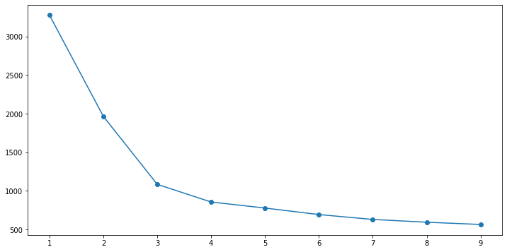

```python
plt.figure(figsize=(12,6))
plt.plot( clusters_df.num_clusters, clusters_df.cluster_errors, marker = "o" )
```

The location of a knee in the plot is usually considered as an indicator of the appropriate number of clusters as it means that adding another cluster does not improve much better the partition.

#### From the plot above, the optimal point of k where an elbow occurs is at 3.

An alternative is to employ the Silhouette Method to find the best k (the optimum number of clusters), which is a better alternative to Elbow Method.

### Silhouette Analysis

Silhouette analysis can be used to study the separation distance between the resulting clusters. The silhouette plot displays a measure of how close each point in one cluster is to points in the neighboring clusters and thus provides a way to assess parameters like number of clusters visually. This measure has a range of [-1,1]. Average silhouette method computes the average silhouette of observations for different values of k. The optimal number of clusters k is the one that maximize the average silhouette over a range of possible values for k. Lets check the silhouette scores for different numbers of clusters.

```python
from matplotlib import cm
from sklearn.metrics import silhouette_samples, silhouette_score

def silh_samp_cluster(clust,  X, start=2, stop=5, metric = 'euclidean'):
    # taken from sebastian Raschkas book Python Machine Learning second edition
    for x in range(start, stop):
        km = clust(n_clusters = x,random_state=42)
        y_km = km.fit_predict(X)
        cluster_labels = np.unique(y_km)
        n_clusters = cluster_labels.shape[0]
        silhouette_vals = silhouette_samples(X, y_km, metric = metric)
        y_ax_lower, y_ax_upper =0,0
        yticks = []
        for i, c in enumerate(cluster_labels):
            c_silhouette_vals = silhouette_vals[y_km == c]
            c_silhouette_vals.sort()
            y_ax_upper += len(c_silhouette_vals)
            color = cm.jet(float(i)/n_clusters)
            plt.barh(range(y_ax_lower, y_ax_upper),
                    c_silhouette_vals,
                    height=1.0,
                    edgecolor='none',
                    color = color)
            yticks.append((y_ax_lower + y_ax_upper)/2.)
            y_ax_lower+= len(c_silhouette_vals)

        silhouette_avg = np.mean(silhouette_vals)
        plt.axvline(silhouette_avg,
                   color = 'red',
                   linestyle = "--")
        plt.yticks(yticks, cluster_labels+1)
        plt.ylabel("Cluster Label")
        plt.xlabel('Silhouette Coefficient')
        plt.title('Silhouette for ' + str(x) + " Clusters")
        plt.show()
```

```python
for x in range(2, 10):
    alg = KMeans(n_clusters = x,random_state=42)
    label = alg.fit_predict(credit_df_scaled)
    print('Average Silhouette-Score for', x,  'Clusters: ', silhouette_score(credit_df_scaled, label))
```

```
Average Silhouette-Score for 2 Clusters:  0.4097731837246822
Average Silhouette-Score for 3 Clusters:  0.4927776132217908
Average Silhouette-Score for 4 Clusters:  0.3845487480615619
Average Silhouette-Score for 5 Clusters:  0.29034340344888737
Average Silhouette-Score for 6 Clusters:  0.2604436420248637
Average Silhouette-Score for 7 Clusters:  0.2630028666456349
Average Silhouette-Score for 8 Clusters:  0.24671329427316513
Average Silhouette-Score for 9 Clusters:  0.2368884711494049
```

### Silhouette plots - K Means

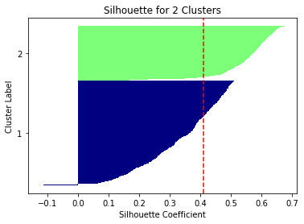

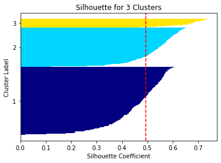

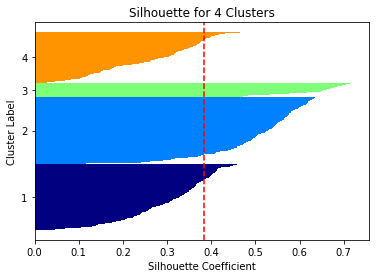

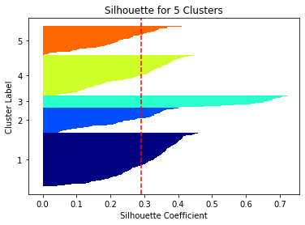

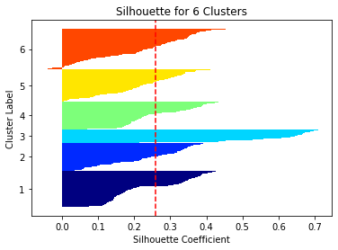

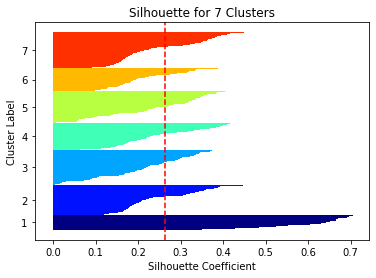

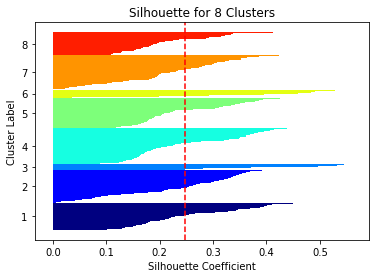

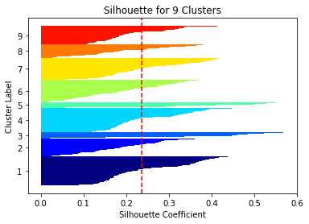

```python
silh_samp_cluster(KMeans, credit_df_scaled, stop=10)
```

The red doted line is the mean/average silhouette score for the cluster in consideration.

For a value to be considered as a good value for number of clusters, the following points should be considered:

- Firstly, The mean value should be as close to 1 as possible
- Secondly, The plot of each cluster should be above the mean value as much as possible. Any plot region below the mean value is not desirable.
- Lastly, the width of the plot should be as uniform as possible.

```python
# So let us create 3 custers

kmeans = KMeans(n_clusters=3, n_init = 5, random_state=42)
kmeans.fit(credit_df_scaled)
```

```
KMeans(n_clusters=3, n_init=5, random_state=42)
```

```python
# Check the number of data in each cluster

labels = kmeans.labels_
counts = np.bincount(labels[labels>=0])
print(counts)
```

```
[383 223  49]
```

```python
kmeans.labels_
```

```
array([0, 1, 0, 0, 1, 2, 1, 1, 1, 1, 1, 1, 1, 1, 1, 1, 1, 1, 1, 1, 1, 1,
       1, 1, 1, 1, 1, 1, 1, 1, 1, 1, 1, 1, 1, 1, 1, 1, 1, 1, 1, 1, 1, 1,
       1, 1, 1, 1, 1, 1, 1, 1, 1, 1, 1, 1, 1, 1, 1, 1, 1, 1, 1, 1, 1, 1,
       1, 1, 1, 1, 1, 1, 1, 1, 1, 1, 1, 1, 1, 1, 1, 1, 1, 1, 1, 1, 1, 1,
       1, 1, 1, 1, 1, 1, 1, 1, 1, 1, 1, 1, 1, 1, 1, 1, 1, 1, 1, 1, 1, 1,
       1, 1, 1, 1, 1, 1, 1, 1, 1, 1, 1, 1, 1, 1, 1, 1, 1, 1, 1, 1, 1, 1,
       1, 1, 1, 1, 1, 1, 1, 1, 1, 1, 1, 1, 1, 1, 1, 1, 1, 1, 1, 1, 1, 1,
       1, 1, 1, 1, 1, 1, 1, 1, 1, 1, 1, 1, 1, 1, 1, 1, 1, 1, 1, 1, 1, 1,
       1, 1, 1, 1, 1, 1, 1, 1, 1, 1, 1, 1, 1, 1, 1, 1, 1, 1, 1, 1, 1, 1,
       1, 1, 1, 1, 1, 1, 1, 1, 1, 1, 1, 1, 1, 1, 1, 1, 1, 1, 1, 1, 1, 1,
       1, 1, 1, 1, 1, 0, 0, 0, 0, 0, 0, 0, 0, 0, 0, 0, 0, 0, 0, 0, 0, 0,
       0, 0, 0, 0, 0, 0, 0, 0, 0, 0, 0, 0, 0, 0, 0, 0, 0, 0, 0, 0, 0, 0,
       0, 0, 0, 0, 0, 0, 0, 0, 0, 0, 0, 0, 0, 0, 0, 0, 0, 0, 0, 0, 0, 1,
       0, 0, 0, 0, 0, 0, 0, 0, 0, 0, 0, 0, 0, 0, 0, 0, 0, 0, 0, 0, 0, 0,
       0, 0, 1, 0, 0, 0, 0, 0, 0, 0, 0, 0, 0, 0, 0, 0, 0, 0, 0, 0, 0, 0,
       0, 0, 0, 0, 0, 0, 0, 0, 0, 0, 0, 0, 0, 0, 0, 0, 0, 0, 0, 0, 0, 0,
       0, 0, 0, 0, 0, 0, 0, 0, 0, 0, 0, 0, 0, 0, 0, 0, 0, 0, 0, 0, 0, 0,
       0, 0, 0, 0, 0, 0, 0, 0, 0, 0, 0, 0, 0, 0, 0, 0, 0, 0, 0, 0, 0, 0,
       0, 0, 0, 0, 0, 0, 0, 0, 0, 0, 0, 0, 0, 0, 0, 0, 0, 0, 0, 0, 0, 0,
       0, 0, 0, 0, 0, 0, 0, 0, 0, 0, 0, 0, 0, 0, 0, 0, 0, 0, 0, 0, 0, 0,
       0, 0, 0, 0, 0, 0, 0, 0, 0, 0, 0, 0, 0, 0, 0, 0, 0, 0, 0, 0, 0, 0,
       0, 0, 0, 0, 0, 0, 0, 0, 0, 0, 0, 0, 0, 0, 0, 0, 0, 0, 0, 0, 0, 0,
       0, 0, 0, 0, 0, 0, 0, 0, 0, 0, 0, 0, 0, 0, 0, 0, 0, 0, 0, 0, 0, 0,
       0, 0, 0, 0, 0, 0, 0, 0, 0, 0, 0, 0, 0, 0, 0, 0, 0, 0, 0, 0, 0, 0,
       0, 0, 0, 0, 0, 0, 0, 0, 0, 0, 0, 0, 0, 0, 0, 0, 0, 0, 0, 0, 0, 0,
       0, 0, 0, 0, 0, 0, 0, 0, 0, 0, 0, 0, 0, 0, 0, 0, 0, 0, 0, 0, 0, 0,
       0, 0, 0, 0, 0, 0, 0, 0, 0, 0, 0, 0, 0, 0, 0, 0, 0, 0, 0, 0, 0, 0,
       0, 0, 0, 0, 0, 0, 0, 0, 0, 0, 0, 0, 0, 2, 2, 2, 2, 2, 2, 2, 2, 2,
       2, 2, 2, 2, 2, 2, 2, 2, 2, 2, 2, 2, 2, 2, 2, 2, 2, 2, 2, 2, 2, 2,
       2, 2, 2, 2, 2, 2, 2, 2, 2, 2, 2, 2, 2, 2, 2, 2, 2], dtype=int32)
```

```python
# Distribution looks fine.

# let us check the centers in each group
centroids = kmeans.cluster_centers_
centroid_df = pd.DataFrame(centroids, columns = list(credit_df_scaled) )
centroid_df.transpose()
```

|  | 0 | 1 | 2 |
| --- | --- | --- | --- |
| Avg_Credit_Limit | 0.172526 | -0.730149 | 1.974406 |
| Total_Credit_Cards | 0.374688 | -1.056966 | 1.881592 |
| Total_visits_bank | 0.665618 | -0.900706 | -1.103557 |
| Total_visits_online | -0.554220 | 0.328658 | 2.836235 |
| Total_calls_made | -0.552118 | 1.143431 | -0.888239 |

### Assign the groups created above to data frame and study the characteristics for each group

```python
# Add cluster number to original cars data

predictions = kmeans.predict(credit_df_scaled)
predictions
credit_df['group'] = predictions
credit_df['group'] = credit_df['group'].astype('category')
credit_df.dtypes
```

```
Sl_No                     int64
Customer Key              int64
Avg_Credit_Limit          int64
Total_Credit_Cards        int64
Total_visits_bank         int64
Total_visits_online       int64
Total_calls_made          int64
group                  category
dtype: object
```

```python
credit_df_scaled['group'] = predictions
```

```python
creditClust = credit_df_scaled.groupby(['group'])
creditClust.mean()
```

| group | Avg_Credit_Limit | Total_Credit_Cards | Total_visits_bank | Total_visits_online | Total_calls_made |
| --- | --- | --- | --- | --- | --- |
| 0 | 0.172526 | 0.374688 | 0.665618 | -0.554220 | -0.552118 |
| 1 | -0.730149 | -1.056966 | -0.900706 | 0.328658 | 1.143431 |
| 2 | 1.974406 | 1.881592 | -1.103557 | 2.836235 | -0.888239 |

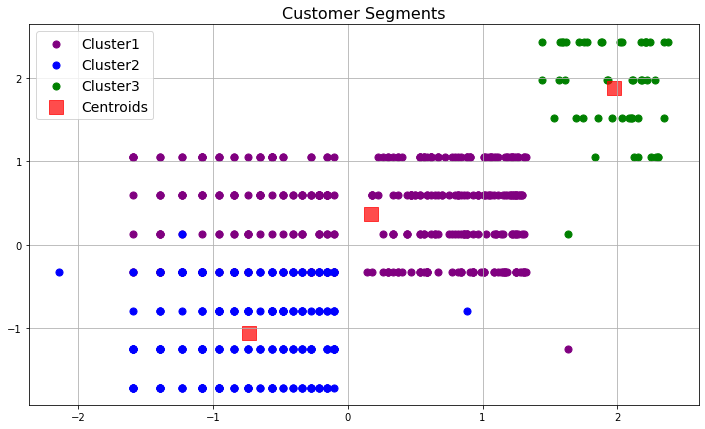

```python
kmeans = KMeans(n_clusters=3,init='k-means++', max_iter=300, n_init=5,random_state=42)
X = credit_df_scaled.values
y_means = kmeans.fit_predict(X)

#Visualizing the clusters
plt.figure(figsize=(12,7))
plt.scatter(X[y_means==0,0],X[y_means==0,1],s=50, c='purple',label='Cluster1')
plt.scatter(X[y_means==1,0],X[y_means==1,1],s=50, c='blue',label='Cluster2')
plt.scatter(X[y_means==2,0],X[y_means==2,1],s=50, c='green',label='Cluster3')
plt.scatter(kmeans.cluster_centers_[:,0], kmeans.cluster_centers_[:,1],s=200,marker='s', c='red', alpha=0.7, label='Centroids');
plt.title('Customer Segments',fontsize=16)
plt.legend(fontsize=14)
plt.grid(True)
```

```
array([[<AxesSubplot:title={'center':'Avg_Credit_Limit'}, xlabel='[group]'>,
        <AxesSubplot:title={'center':'Total_Credit_Cards'}, xlabel='[group]'>,
        <AxesSubplot:title={'center':'Total_calls_made'}, xlabel='[group]'>,
        <AxesSubplot:title={'center':'Total_visits_bank'}, xlabel='[group]'>],
       [<AxesSubplot:title={'center':'Total_visits_online'}, xlabel='[group]'>,
        <AxesSubplot:>, <AxesSubplot:>, <AxesSubplot:>],
       [<AxesSubplot:>, <AxesSubplot:>, <AxesSubplot:>, <AxesSubplot:>]],
      dtype=object)
```

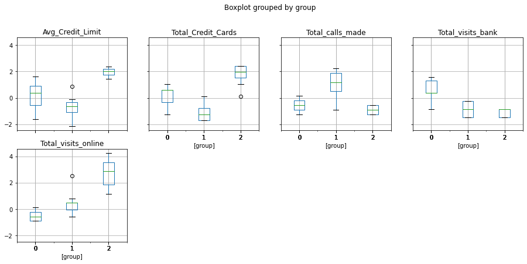

```python
# Visualize the centers

credit_df_scaled["group"] = predictions
credit_df_scaled.boxplot(by = 'group',  layout=(3,4), figsize=(15, 10))
```

```python
credit_df_scaled
```

|  | Avg_Credit_Limit | Total_Credit_Cards | Total_visits_bank | Total_visits_online | Total_calls_made | group |
| --- | --- | --- | --- | --- | --- | --- |
| 0 | 1.631391 | -1.249084 | -0.864813 | -0.548851 | -1.252966 | 0 |
| 1 | 0.885986 | -0.788414 | -1.480522 | 2.535493 | 1.900849 | 1 |
| 2 | 0.885986 | 1.054266 | -0.864813 | 0.136559 | 0.148730 | 0 |
| 3 | 0.336649 | 0.132926 | -0.864813 | -0.548851 | 0.148730 | 0 |
| 5 | -0.099385 | -0.788414 | -1.480522 | -0.548851 | 1.550425 | 1 |
| ... | ... | ... | ... | ... | ... | ... |
| 655 | 1.620583 | 2.436277 | -0.864813 | 2.535493 | -1.252966 | 2 |
| 656 | 1.443893 | 2.436277 | -0.864813 | 3.563608 | -0.552118 | 2 |
| 657 | 2.030968 | 1.514937 | -0.864813 | 2.192789 | -0.902542 | 2 |
| 658 | 2.214602 | 2.436277 | -0.864813 | 4.249018 | -1.252966 | 2 |
| 659 | 2.182877 | 1.975607 | -1.480522 | 3.220903 | -0.552118 | 2 |

655 rows × 6 columns

```python
credit_df
```

|  | Sl_No | Customer Key | Avg_Credit_Limit | Total_Credit_Cards | Total_visits_bank | Total_visits_online | Total_calls_made | group |
| --- | --- | --- | --- | --- | --- | --- | --- | --- |
| 0 | 1 | 87073 | 100000 | 2 | 1 | 1 | 0 | 0 |
| 1 | 2 | 38414 | 50000 | 3 | 0 | 10 | 9 | 1 |
| 2 | 3 | 17341 | 50000 | 7 | 1 | 3 | 4 | 0 |
| 3 | 4 | 40496 | 30000 | 5 | 1 | 1 | 4 | 0 |
| 5 | 6 | 58634 | 20000 | 3 | 0 | 1 | 8 | 1 |
| ... | ... | ... | ... | ... | ... | ... | ... | ... |
| 655 | 656 | 51108 | 99000 | 10 | 1 | 10 | 0 | 2 |
| 656 | 657 | 60732 | 84000 | 10 | 1 | 13 | 2 | 2 |
| 657 | 658 | 53834 | 145000 | 8 | 1 | 9 | 1 | 2 |
| 658 | 659 | 80655 | 172000 | 10 | 1 | 15 | 0 | 2 |
| 659 | 660 | 80150 | 167000 | 9 | 0 | 12 | 2 | 2 |

655 rows × 8 columns

```python
credit_df = credit_df.drop(['group'], axis=1)
credit_df_scaled = credit_df_scaled.drop(['group'], axis=1)
```

```python
credit_df
```

|  | Sl_No | Customer Key | Avg_Credit_Limit | Total_Credit_Cards | Total_visits_bank | Total_visits_online | Total_calls_made |
| --- | --- | --- | --- | --- | --- | --- | --- |
| 0 | 1 | 87073 | 100000 | 2 | 1 | 1 | 0 |
| 1 | 2 | 38414 | 50000 | 3 | 0 | 10 | 9 |
| 2 | 3 | 17341 | 50000 | 7 | 1 | 3 | 4 |
| 3 | 4 | 40496 | 30000 | 5 | 1 | 1 | 4 |
| 5 | 6 | 58634 | 20000 | 3 | 0 | 1 | 8 |
| ... | ... | ... | ... | ... | ... | ... | ... |
| 655 | 656 | 51108 | 99000 | 10 | 1 | 10 | 0 |
| 656 | 657 | 60732 | 84000 | 10 | 1 | 13 | 2 |
| 657 | 658 | 53834 | 145000 | 8 | 1 | 9 | 1 |
| 658 | 659 | 80655 | 172000 | 10 | 1 | 15 | 0 |
| 659 | 660 | 80150 | 167000 | 9 | 0 | 12 | 2 |

655 rows × 7 columns

```python
credit_df_scaled
```

|  | Avg_Credit_Limit | Total_Credit_Cards | Total_visits_bank | Total_visits_online | Total_calls_made |
| --- | --- | --- | --- | --- | --- |
| 0 | 1.631391 | -1.249084 | -0.864813 | -0.548851 | -1.252966 |
| 1 | 0.885986 | -0.788414 | -1.480522 | 2.535493 | 1.900849 |
| 2 | 0.885986 | 1.054266 | -0.864813 | 0.136559 | 0.148730 |
| 3 | 0.336649 | 0.132926 | -0.864813 | -0.548851 | 0.148730 |
| 5 | -0.099385 | -0.788414 | -1.480522 | -0.548851 | 1.550425 |
| ... | ... | ... | ... | ... | ... |
| 655 | 1.620583 | 2.436277 | -0.864813 | 2.535493 | -1.252966 |
| 656 | 1.443893 | 2.436277 | -0.864813 | 3.563608 | -0.552118 |
| 657 | 2.030968 | 1.514937 | -0.864813 | 2.192789 | -0.902542 |
| 658 | 2.214602 | 2.436277 | -0.864813 | 4.249018 | -1.252966 |
| 659 | 2.182877 | 1.975607 | -1.480522 | 3.220903 | -0.552118 |

655 rows × 5 columns

## Hierarchical Clustering

```python
from scipy.cluster.hierarchy import cophenet, dendrogram, linkage
```

```python
from scipy.spatial.distance import pdist  #Pairwise distribution between data points
```

#### Find out the linkage matrix

```python
# Use ward as linkage metric and distance as Eucledian and generate the linkage matrix
Z = linkage(credit_df_scaled, 'ward', metric='euclidean')
Z.shape
```

```
(654, 4)
```

```python
Z[:]
```

```
array([[ 459.        ,  492.        ,    0.        ,    2.        ],
       [ 420.        ,  450.        ,    0.        ,    2.        ],
       [  28.        ,  212.        ,    0.        ,    2.        ],
       ...,
       [1303.        , 1305.        ,   21.02506121,  385.        ],
       [1302.        , 1306.        ,   41.97085874,  434.        ],
       [1304.        , 1307.        ,   51.15864002,  655.        ]])
```

#### Plot the dendrogram for the consolidated dataframe

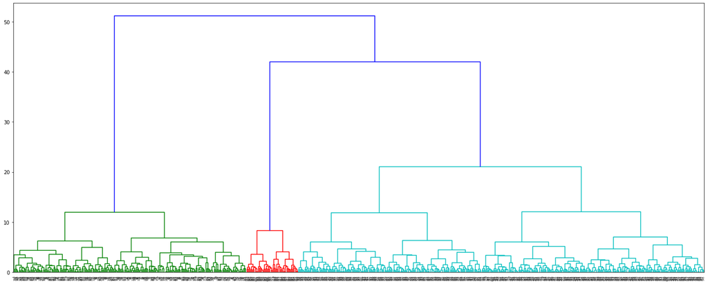

```python
plt.figure(figsize=(25, 10))
dendrogram(Z)
plt.show()
```

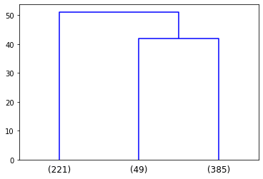

```python
# Hint: Use truncate_mode='lastp' attribute in dendrogram function to arrive at dendrogram
dendrogram(
    Z,
    truncate_mode='lastp',  # show only the last p merged clusters
    p=3,  # show only the last p merged clusters
)
plt.show()
```

Cutting a dendrogram at a certain level gives a set of clusters. To select the "best cut" in dendrograms (i.e., cutting a dendrogram at a particular height) of hierarchical cluster analysis, one of the techniques that can be used is to cut the dendrogram where the difference is most significant. In other words, take the largest difference of heights and count the number of vertical lines seen and that can be the number of clusters. Based on this theory, the optimum number of clusters is 3.

The optimal number of clusters can also be determined by using a mathematical technique such as the silhouette scores.

### Silhouette Scores - Agglomerative Clustering

```python
from sklearn.cluster import AgglomerativeClustering
```

```python
silhouette_scores = []
for n_cluster in range(2, 10):
    print('Average Silhouette-Score for', n_cluster,  'Clusters: ', silhouette_score(credit_df_scaled, AgglomerativeClustering(n_clusters = n_cluster).fit_predict(credit_df_scaled)))
    silhouette_scores.append(
        silhouette_score(credit_df_scaled, AgglomerativeClustering(n_clusters = n_cluster).fit_predict(credit_df_scaled)))
```

```
Average Silhouette-Score for 2 Clusters:  0.40986410900819525
Average Silhouette-Score for 3 Clusters:  0.4927229114984107
Average Silhouette-Score for 4 Clusters:  0.37700358822472824
Average Silhouette-Score for 5 Clusters:  0.33392117941720834
Average Silhouette-Score for 6 Clusters:  0.2381836979881422
Average Silhouette-Score for 7 Clusters:  0.2438034335199622
Average Silhouette-Score for 8 Clusters:  0.22701104921683143
Average Silhouette-Score for 9 Clusters:  0.2139600011641599
```

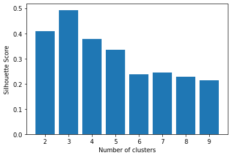

```python
# Plotting a bar graph to compare the results
k = [2, 3, 4, 5, 6,7,8,9]
plt.bar(k, silhouette_scores)
plt.xlabel('Number of clusters', fontsize = 10)
plt.ylabel('Silhouette Score', fontsize = 10)
plt.show()
```

#### From the barplot above, it can be concluded that for the given data and clustering technique, the optimal number of clusters is 3 (with the highest silhoutte score, closest to +1), similar to K-Means technique.

Cophenet index is a measure of the correlation between the distance of points in feature space and distance on dendrogram. The closer it is to 1, the better is the clustering.

```python
# Average linkage

Z = linkage(credit_df_scaled, metric='euclidean', method='average')
c, coph_dists = cophenet(Z , pdist(credit_df_scaled))

c
```

```
0.8702112208842007
```

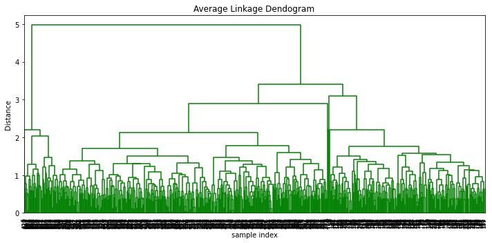

```python
plt.figure(figsize=(10, 5))
plt.title('Average Linkage Dendogram')
plt.xlabel('sample index')
plt.ylabel('Distance')
dendrogram(Z, leaf_rotation=90.,color_threshold = 40, leaf_font_size=8. )
plt.tight_layout()
```

```python
# Single linkage

Z = linkage(credit_df_scaled, metric='euclidean', method='single')
c, coph_dists = cophenet(Z , pdist(credit_df_scaled))

c
```

```
0.6913175139671595
```

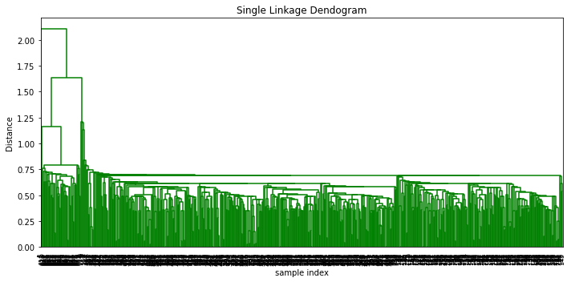

```python
plt.figure(figsize=(10, 5))
plt.title('Single Linkage Dendogram')
plt.xlabel('sample index')
plt.ylabel('Distance')
dendrogram(Z, leaf_rotation=90.,color_threshold = 40, leaf_font_size=8. )
plt.tight_layout()
```

```python
# Complete linkage

Z = linkage(credit_df_scaled, metric='euclidean', method='complete')
c, coph_dists = cophenet(Z , pdist(credit_df_scaled))

c
```

```
0.8420286172999812
```

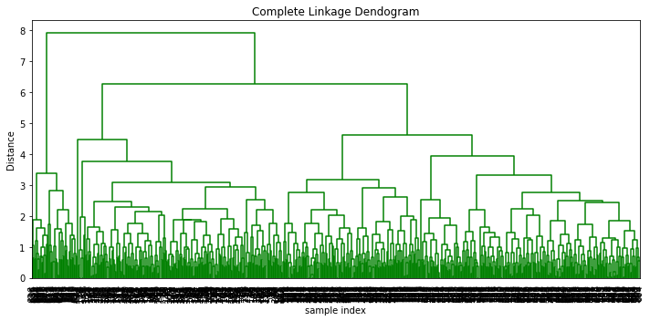

```python
plt.figure(figsize=(10, 5))
plt.title('Complete Linkage Dendogram')
plt.xlabel('sample index')
plt.ylabel('Distance')
dendrogram(Z, leaf_rotation=90.,color_threshold=90,  leaf_font_size=10. )
plt.tight_layout()
```

```python
# Ward linkage

Z = linkage(credit_df_scaled, metric='euclidean', method='ward')
c, coph_dists = cophenet(Z , pdist(credit_df_scaled))

c
```

```
0.7449558040281822
```

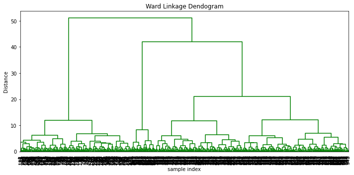

```python
plt.figure(figsize=(10, 5))
plt.title('Ward Linkage Dendogram')
plt.xlabel('sample index')
plt.ylabel('Distance')
dendrogram(Z, leaf_rotation=90.,color_threshold=600,  leaf_font_size=10. )
plt.tight_layout()
```

```python
# Median linkage
Z = linkage(credit_df_scaled, metric='euclidean', method='median')
c, coph_dists = cophenet(Z , pdist(credit_df_scaled))

c
```

```
0.8511901819877485
```

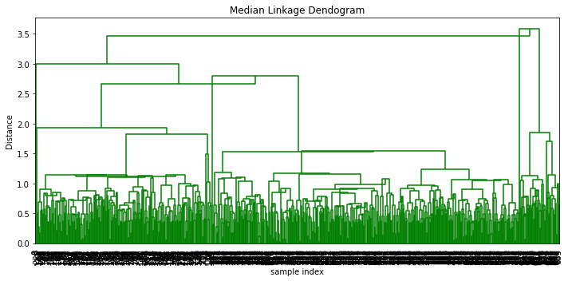

```python
plt.figure(figsize=(10, 5))
plt.title('Median Linkage Dendogram')
plt.xlabel('sample index')
plt.ylabel('Distance')
dendrogram(Z, leaf_rotation=90.,color_threshold=600,  leaf_font_size=10. )
plt.tight_layout()
```

#### The average linkage has the highest cophenetic coeff among all the linkage techinques tried for hierarchal clustering.

### Build the model

```python
model = AgglomerativeClustering(n_clusters=3, affinity='euclidean',  linkage='average')
```

```python
model.fit(credit_df_scaled)
```

```
AgglomerativeClustering(linkage='average', n_clusters=3)
```

```python
L = model.labels_
L
```

```
array([2, 0, 2, 2, 0, 1, 2, 0, 0, 0, 0, 0, 0, 0, 0, 0, 0, 0, 0, 0, 0, 0,
       0, 0, 0, 0, 0, 0, 0, 0, 0, 0, 0, 0, 0, 0, 0, 0, 0, 0, 0, 0, 0, 0,
       0, 0, 0, 0, 0, 0, 0, 0, 0, 0, 0, 0, 0, 0, 0, 0, 0, 0, 0, 0, 0, 0,
       0, 0, 0, 0, 0, 0, 0, 0, 0, 0, 0, 0, 0, 0, 0, 0, 0, 0, 0, 0, 0, 0,
       0, 0, 0, 0, 0, 0, 0, 0, 0, 0, 0, 0, 0, 0, 0, 0, 0, 0, 0, 0, 0, 0,
       0, 0, 0, 0, 0, 0, 0, 0, 0, 0, 0, 0, 0, 0, 0, 0, 0, 0, 0, 0, 0, 0,
       0, 0, 0, 0, 0, 0, 0, 0, 0, 0, 0, 0, 0, 0, 0, 0, 0, 0, 0, 0, 0, 0,
       0, 0, 0, 0, 0, 0, 0, 0, 0, 0, 0, 0, 0, 0, 0, 0, 0, 0, 0, 0, 0, 0,
       0, 0, 0, 0, 0, 0, 0, 0, 0, 0, 0, 0, 0, 0, 0, 0, 0, 0, 0, 0, 0, 0,
       0, 0, 0, 0, 0, 0, 0, 0, 0, 0, 0, 0, 0, 0, 0, 0, 0, 0, 0, 0, 0, 0,
       0, 0, 0, 0, 0, 2, 2, 2, 2, 2, 2, 2, 2, 2, 2, 2, 2, 2, 2, 2, 2, 2,
       2, 2, 2, 2, 2, 2, 2, 2, 2, 2, 2, 2, 2, 2, 2, 2, 2, 2, 2, 2, 2, 2,
       2, 2, 2, 2, 2, 2, 2, 2, 2, 2, 2, 2, 2, 2, 2, 2, 2, 2, 2, 2, 2, 0,
       2, 2, 2, 2, 2, 2, 2, 2, 2, 2, 2, 2, 2, 2, 2, 2, 2, 2, 2, 2, 2, 2,
       2, 2, 0, 2, 2, 2, 2, 2, 2, 2, 2, 2, 2, 2, 2, 2, 2, 2, 2, 2, 2, 2,
       2, 2, 2, 2, 2, 2, 2, 2, 2, 2, 2, 2, 2, 2, 2, 2, 2, 2, 2, 2, 2, 2,
       2, 2, 2, 2, 2, 2, 2, 2, 2, 2, 2, 2, 2, 2, 2, 2, 2, 2, 2, 2, 2, 2,
       2, 2, 2, 2, 2, 2, 2, 2, 2, 2, 2, 2, 2, 2, 2, 2, 2, 2, 2, 2, 2, 2,
       2, 2, 2, 2, 2, 2, 2, 2, 2, 2, 2, 2, 2, 2, 2, 2, 2, 2, 2, 2, 2, 2,
       2, 2, 2, 2, 2, 2, 2, 2, 2, 2, 2, 2, 2, 2, 2, 2, 2, 2, 2, 2, 2, 2,
       2, 2, 2, 2, 2, 2, 2, 2, 2, 2, 2, 2, 2, 2, 2, 2, 2, 2, 2, 2, 2, 2,
       2, 2, 2, 2, 2, 2, 2, 2, 2, 2, 2, 2, 2, 2, 2, 2, 2, 2, 2, 2, 2, 2,
       2, 2, 2, 2, 2, 2, 2, 2, 2, 2, 2, 2, 2, 2, 2, 2, 2, 2, 2, 2, 2, 2,
       2, 2, 2, 2, 2, 2, 2, 2, 2, 2, 2, 2, 2, 2, 2, 2, 2, 2, 2, 2, 2, 2,
       2, 2, 2, 2, 2, 2, 2, 2, 2, 2, 2, 2, 2, 2, 2, 2, 2, 2, 2, 2, 2, 2,
       2, 2, 2, 2, 2, 2, 2, 2, 2, 2, 2, 2, 2, 2, 2, 2, 2, 2, 2, 2, 2, 2,
       2, 2, 2, 2, 2, 2, 2, 2, 2, 2, 2, 2, 2, 2, 2, 2, 2, 2, 2, 2, 2, 2,
       2, 2, 2, 2, 2, 2, 2, 2, 2, 2, 2, 2, 2, 1, 1, 1, 1, 1, 1, 1, 1, 1,
       1, 1, 1, 1, 1, 1, 1, 1, 1, 1, 1, 1, 1, 1, 1, 1, 1, 1, 1, 1, 1, 1,
       1, 1, 1, 1, 1, 1, 1, 1, 1, 1, 1, 1, 1, 1, 1, 1, 1])
```

```python
credit_df['labels'] = model.labels_
credit_df.head(10)
```

|  | Sl_No | Customer Key | Avg_Credit_Limit | Total_Credit_Cards | Total_visits_bank | Total_visits_online | Total_calls_made | labels |
| --- | --- | --- | --- | --- | --- | --- | --- | --- |
| 0 | 1 | 87073 | 100000 | 2 | 1 | 1 | 0 | 2 |
| 1 | 2 | 38414 | 50000 | 3 | 0 | 10 | 9 | 0 |
| 2 | 3 | 17341 | 50000 | 7 | 1 | 3 | 4 | 2 |
| 3 | 4 | 40496 | 30000 | 5 | 1 | 1 | 4 | 2 |
| 5 | 6 | 58634 | 20000 | 3 | 0 | 1 | 8 | 0 |
| 6 | 7 | 48370 | 100000 | 5 | 0 | 11 | 2 | 1 |
| 7 | 8 | 37376 | 15000 | 3 | 0 | 1 | 1 | 2 |
| 8 | 9 | 82490 | 5000 | 2 | 0 | 2 | 2 | 0 |
| 9 | 10 | 44770 | 3000 | 4 | 0 | 1 | 7 | 0 |
| 10 | 11 | 52741 | 10000 | 4 | 0 | 5 | 5 | 0 |

```python
credit_df_scaled['labels'] = model.labels_
```

```python
credit_h_Clust = credit_df_scaled.groupby(['labels'])
```

```python
print(list(credit_h_Clust))
```

```
[(0,      Avg_Credit_Limit  Total_Credit_Cards  Total_visits_bank  \
1            0.885986           -0.788414          -1.480522
5           -0.099385           -0.788414          -1.480522
8           -1.590195           -1.249084          -1.480522
9           -2.139532           -0.327744          -1.480522
10          -0.844790           -0.327744          -1.480522
..                ...                 ...                ...
225         -0.339352           -0.327744          -0.864813
226         -1.084757           -1.709754          -0.249104
227         -1.084757           -1.249084          -0.249104
288         -1.228355            0.132926          -0.249104
313         -1.228355           -0.327744          -0.249104

     Total_visits_online  Total_calls_made  labels
1               2.535493          1.900849       0
```

[output cut: 138 more lines]

```python
credit_h_Clust.mean()
```

| labels | Avg_Credit_Limit | Total_Credit_Cards | Total_visits_bank | Total_visits_online | Total_calls_made |
| --- | --- | --- | --- | --- | --- |
| 0 | -0.731597 | -1.058176 | -0.898094 | 0.332611 | 1.152647 |
| 1 | 1.974406 | 1.881592 | -1.103557 | 2.836235 | -0.888239 |
| 2 | 0.171012 | 0.371659 | 0.660029 | -0.554206 | -0.553031 |

```python
hc = AgglomerativeClustering(n_clusters=3, affinity='euclidean',  linkage='average')
X = credit_df_scaled.values
y_hc = hc.fit_predict(X)
```

```python
y_hc.shape
```

```
(655,)
```

```python
X.shape
```

```
(655, 6)
```

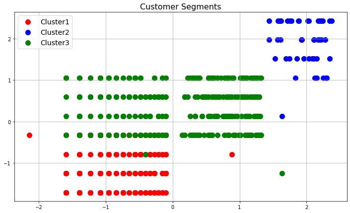

```python
#Visualize the clusters
plt.figure(figsize=(12,7))
plt.scatter(X[y_hc == 0, 0], X[y_hc == 0, 1], s = 100, c = 'red', label = 'Cluster1')
plt.scatter(X[y_hc == 1, 0], X[y_hc == 1, 1], s = 100, c = 'blue', label = 'Cluster2')
plt.scatter(X[y_hc == 2, 0], X[y_hc == 2, 1], s = 100, c = 'green', label = 'Cluster3');
plt.title('Customer Segments',fontsize=16)
plt.legend(fontsize=14)
plt.grid(True)
```

```
array([[<AxesSubplot:title={'center':'Avg_Credit_Limit'}, xlabel='[labels]'>,
        <AxesSubplot:title={'center':'Total_Credit_Cards'}, xlabel='[labels]'>,
        <AxesSubplot:title={'center':'Total_calls_made'}, xlabel='[labels]'>,
        <AxesSubplot:title={'center':'Total_visits_bank'}, xlabel='[labels]'>],
       [<AxesSubplot:title={'center':'Total_visits_online'}, xlabel='[labels]'>,
        <AxesSubplot:>, <AxesSubplot:>, <AxesSubplot:>]], dtype=object)
```

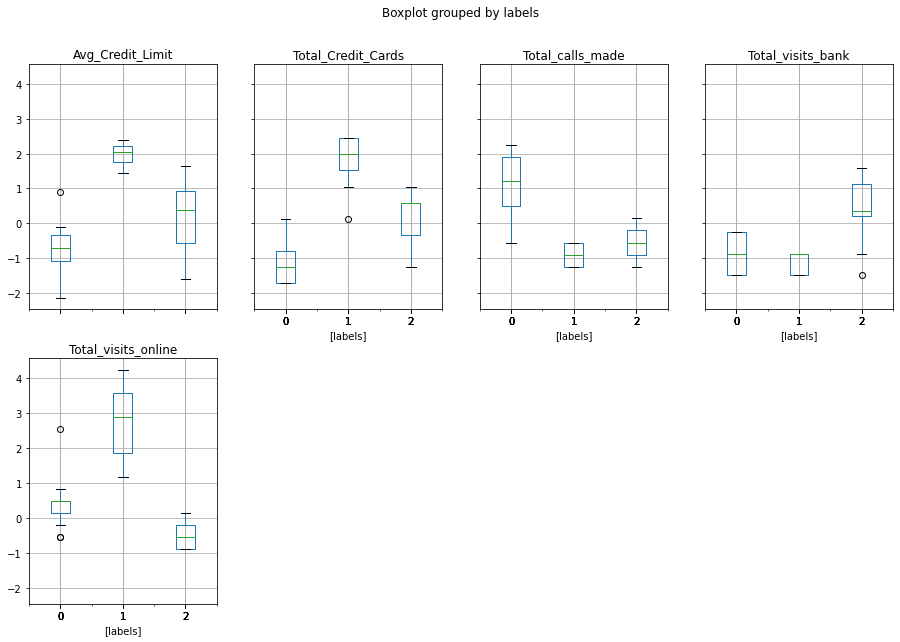

```python
credit_df_scaled.boxplot(by='labels', layout = (2,4),figsize=(15,10))
```

### Summary

Both the clustering techniques used above (K-Means and Agglomerative Hierarchial clustering) seem to segment the customers into essentially the same number of clusters and based on similar criteria. The customers are segmented based on their average credit limit across all their credit cards.

The customers with the least average credit limit (consequently the lowest total number of credit cards) seem to prefer calling the bank rather than in person visits and online high number of total calls to the bank.

The customers with Highest average credit limit and high number of credit cards, seem to higher number of total visits online. This group also seems to have lower number of total calls and lower number of total visits to bank indicating that their preferred channel of communication is online.

Better online marketing and service/support strategies targeting this group of customers should be considered.

There are also customers with moderate average credit limit and total number of credit cards, and their preferred mode of communication seem to be in person bank visits. To expand their customer base and attract these customers, the bank needs to incorporate better in person service/support strategies as well.